# HW 22

Harsha

2024-04-11

Here, we are examining the relationship between petal.area and petal.length from the iris_measurements.csv file on iris flowers. We are fitting a first order linear model of

$petal.area= m*petal.length+b+ϵ$, where ϵ is a constant that does not vary as a function of varying petal.length. We will first graph these two continuous variables in the scatterplot below.

### Import libraries

```r
library(ggplot2)
library(tidyr)
```

### Scatterplot

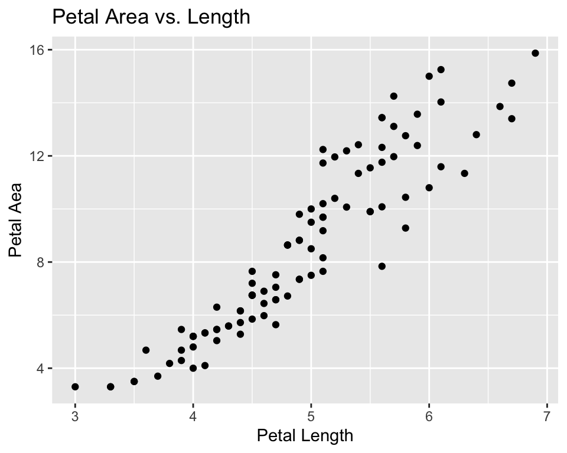

```r
df <- read.csv("iris_measurements.csv") %>%
  pivot_wider(names_from = type,
            values_from = value)

# Plot the data
ggplot(df, aes(x=petal.length, y=petal.area)) + geom_point() +
  xlab("Petal Length") + ylab("Petal Aea") + ggtitle("Petal Area vs. Length ")
```

From first look, it seems like a linear model is indeed a good fit. But we have to make sure the conditions are satisfied first before we attempt to fit a linear model. These assumptions include linearity, equal variance in the residuals, independence. Let’s start with independence first. Just because a certain flower has a petal.area and petal.length, in theory this should not influence these measurements in a nearby flower. We may assume the datapoints for each flower are independent of one another. For linearity, the scatterplot above seems to suggest that a linear model would be a good fit. Most of the points fall on a positive slope line. We can vertify this condition and equal variance with the residual-dependence diagnostic plot below.

### Residual-Dependence diagnostic plot

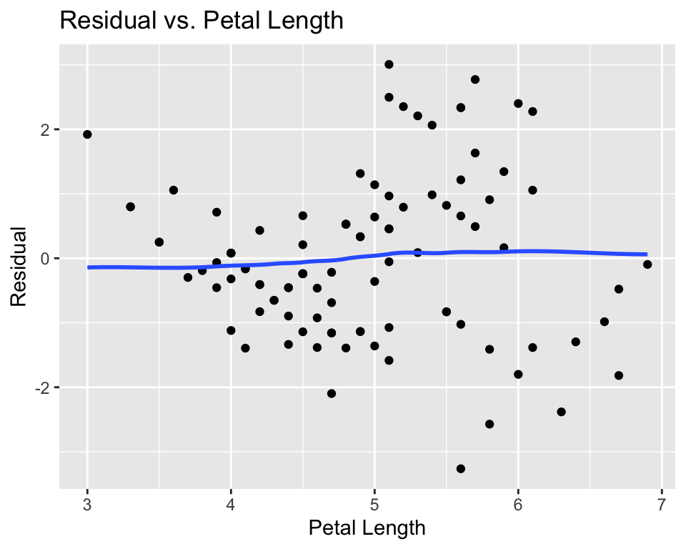

```r
#Fit the model
M1 <- lm(petal.area ~ petal.length, data= df)
coefficients(M1)
df$resid1 <- residuals(M1)

#residual-dependence diagnostic plot
ggplot(df, aes(x = petal.length, y = resid1)) + geom_point() +
            stat_smooth(method = "loess", se = FALSE, span = 1,
            method.args = list(degree = 1) ) +
  xlab("Petal Length") + ylab("Residual") +
  ggtitle("Residual vs. Petal Length ")
```

[output not shown]

### Spread-location diagnostic plot;

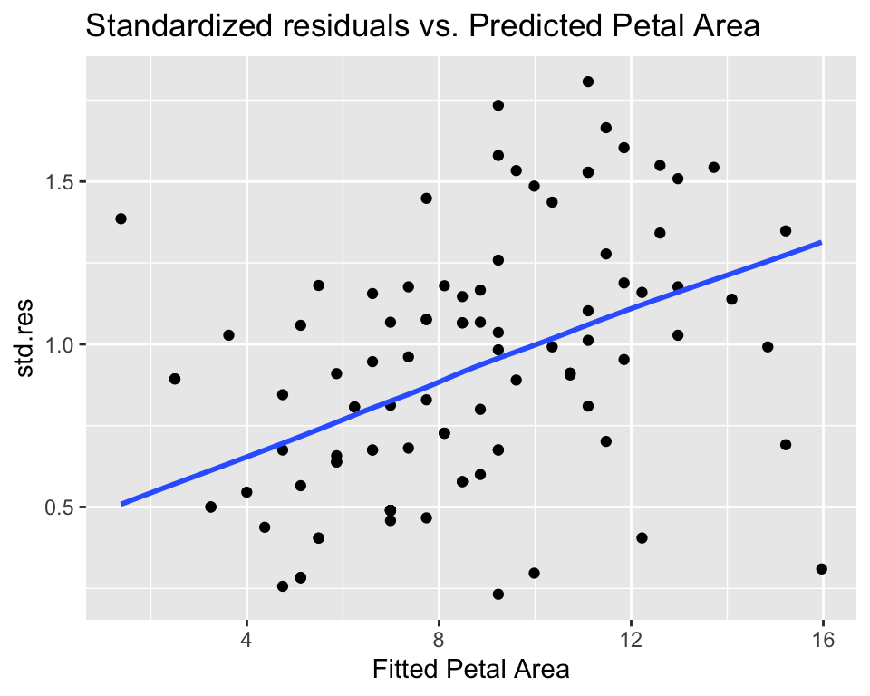

```r
sl <- data.frame(std.res = sqrt(abs(df$resid1)), fit = predict(M1))
ggplot(sl, aes (fit, std.res)) + geom_point() +
  stat_smooth(method = "loess", se = FALSE, span = 2,
              method.args = list(degree = 1)) + xlab("Fitted Petal Area") +
  ggtitle("Standardized residuals vs. Predicted Petal Area ")
```

Here, the residuals be increasing, meaning as predicted petal area increases, so does the standardized residuals This does not imply constant residuals or epislon. There is a montonic increase. Hence, we should not fit a linear model.